# Objective 2

Bui, Andy

2026-09-25

```r
library(caret)
library(dplyr)
library(boot)
#Reading Data
ins <- read.csv("../data/insurance.csv")

#Data Cleanup
ins <- ins %>% distinct() %>% mutate(smoker = factor(smoker, levels = c("no", "yes"))
                                     , region = factor(region, levels = c("northeast", "northwest", "southeast", "southwest")),
                                     sex = factor(sex, levels = c("female", "male")))

set.seed(1234)

#Splitting Data 80/20
trainIndices = sample(seq(1:length(ins$age)), round(.8 * length(ins$age)))
train = ins[trainIndices, ]
test  = ins[-trainIndices, ]


#Ensuring data is split
nrow(train)
```

```
## [1] 1070
```

```r
nrow(test)
```

```
## [1] 267
```

## Model 1

The baseline predictive model is the final MLR developed in Objective 1. This model will be used as a benchmark to determine whether additional  
model complexity improves out of sample prediction.

```r
#Baseline model from Objective 1
model1 <- lm( charges ~ age + children + bmi * smoker + region, data = train)

summary(model1)
```

```
##
## Call:
## lm(formula = charges ~ age + children + bmi * smoker + region,
##     data = train)
##
## Residuals:
##    Min     1Q Median     3Q    Max
## -15502  -1919  -1294   -424  30175
##
## Coefficients:
##                  Estimate Std. Error t value Pr(>|t|)
## (Intercept)      -2435.68     970.64  -2.509  0.01224 *
## age                263.37      10.88  24.210  < 2e-16 ***
## children           528.17     126.22   4.184 3.09e-05 ***
## bmi                 22.48      29.23   0.769  0.44209
## smokeryes       -20832.99    1901.45 -10.956  < 2e-16 ***
## regionnorthwest   -465.33     431.41  -1.079  0.28100
## regionsoutheast  -1411.04     435.21  -3.242  0.00122 **
## regionsouthwest  -1213.20     432.42  -2.806  0.00511 **
## bmi:smokeryes     1467.85      60.98  24.069  < 2e-16 ***
## ---
## Signif. codes:  0 '***' 0.001 '**' 0.01 '*' 0.05 '.' 0.1 ' ' 1
##
## Residual standard error: 4931 on 1061 degrees of freedom
## Multiple R-squared:  0.8367, Adjusted R-squared:  0.8355
## F-statistic: 679.5 on 8 and 1061 DF,  p-value: < 2.2e-16
```

### Bootstrap Model 1

```r
library(lmboot)
#Baseline model from Objective 1
set.seed(1234)

#Paired Bootstrap
boot.model1 <- paired.boot(charges ~ age + children + bmi * smoker + region,data = train,B = 2000,seed = 1234)

#Bootstrap Intervals
t(apply(boot.model1$bootEstParam, 2, quantile,probs = c(.025, .975)))
```

```
##                         2.5%        97.5%
## (Intercept)      -4131.19839   -655.60146
## age                241.61952    285.68269
## children           299.15757    763.49055
## bmi                -26.73248     70.14266
## smokeryes       -25513.44632 -16386.13486
## regionnorthwest  -1353.69378    491.17178
## regionsoutheast  -2282.25156   -458.44669
## regionsouthwest  -2025.72512   -347.79810
## bmi:smokeryes     1325.87059   1622.80450
```

```r
#Traditional Intervals
confint(model1)
```

```
##                        2.5 %       97.5 %
## (Intercept)      -4340.25899   -531.09119
## age                242.02784    284.71960
## children           280.49616    775.83487
## bmi                -34.87612     79.82639
## smokeryes       -24564.01685 -17101.96112
## regionnorthwest  -1311.85076    381.18618
## regionsoutheast  -2265.00738   -557.07008
## regionsouthwest  -2061.69755   -364.70267
## bmi:smokeryes     1348.18134   1587.50881
```

## More Complex Model

This next model focuses more heavily on prediction than interpretation. Residual analysis from Objective 1 suggested some curvature at higher BMI values.  
Objective 1 also found evidence that the BMI relationship may differ by region ($BMI \times Region,\ p=0.011$). A larger candidate MLR is  
considered that includes additional interactions and a quadratic BMI term. The following model will use feature selection to reduce the candidate model.

```r
full_model <- lm(charges ~ age + sex + children + region + smoker * (bmi + I(bmi^2)) + bmi:region +smoker:region, data = train)

summary(full_model)
```

```
##
## Call:
## lm(formula = charges ~ age + sex + children + region + smoker *
##     (bmi + I(bmi^2)) + bmi:region + smoker:region, data = train)
##
## Residuals:
##      Min       1Q   Median       3Q      Max
## -10077.4  -1920.4  -1242.8   -333.1  30060.8
##
## Coefficients:
##                             Estimate Std. Error t value Pr(>|t|)
## (Intercept)               -4.314e+03  3.760e+03  -1.147   0.2515
## age                        2.620e+02  1.086e+01  24.121  < 2e-16 ***
## sexmale                   -4.189e+02  3.036e+02  -1.380   0.1679
## children                   5.352e+02  1.261e+02   4.245 2.38e-05 ***
## regionnorthwest           -8.148e+02  2.358e+03  -0.346   0.7298
## regionsoutheast            3.926e+03  2.443e+03   1.607   0.1083
## regionsouthwest           -2.624e+02  2.294e+03  -0.114   0.9089
## smokeryes                 -3.311e+04  7.057e+03  -4.692 3.06e-06 ***
## bmi                        1.164e+02  2.398e+02   0.485   0.6275
## I(bmi^2)                  -6.544e-01  3.899e+00  -0.168   0.8667
## smokeryes:bmi              2.248e+03  4.569e+02   4.921 1.00e-06 ***
## smokeryes:I(bmi^2)        -1.177e+01  7.224e+00  -1.630   0.1035
## regionnorthwest:bmi        9.745e+00  7.963e+01   0.122   0.9026
## regionsoutheast:bmi       -1.623e+02  7.689e+01  -2.110   0.0351 *
## regionsouthwest:bmi       -3.932e+01  7.553e+01  -0.521   0.6028
## regionnorthwest:smokeryes  4.666e+00  1.122e+03   0.004   0.9967
## regionsoutheast:smokeryes -7.462e+02  1.048e+03  -0.712   0.4766
## regionsouthwest:smokeryes  6.117e+02  1.111e+03   0.551   0.5820
## ---
## Signif. codes:  0 '***' 0.001 '**' 0.01 '*' 0.05 '.' 0.1 ' ' 1
##
## Residual standard error: 4908 on 1052 degrees of freedom
## Multiple R-squared:  0.8396, Adjusted R-squared:  0.837
## F-statistic: 323.9 on 17 and 1052 DF,  p-value: < 2.2e-16
```

Compared with Model 1, we’re allowing:  
$BMI^2$  
for curvature,  
$BMI * Region$  
for different BMI relationships across regions,  
$Smoker * Region$  
for different smoking relationships across regions. We also allow sex back into the candidate model because Objective 2 is about prediction rather than significance alone.

## Feature Selection

Feature selection using backward stepwise selection

```r
model2 <- step(full_model, direction = "backward", trace = 0)

summary(model2)
```

```
##
## Call:
## lm(formula = charges ~ age + sex + children + region + smoker +
##     bmi + I(bmi^2) + smoker:bmi + smoker:I(bmi^2), data = train)
##
## Residuals:
##      Min       1Q   Median       3Q      Max
## -10161.2  -1898.1  -1298.4   -413.5  29635.3
##
## Coefficients:
##                      Estimate Std. Error t value Pr(>|t|)
## (Intercept)         -6371.098   3468.552  -1.837  0.06652 .
## age                   262.422     10.838  24.213  < 2e-16 ***
## sexmale              -431.560    302.857  -1.425  0.15446
## children              545.195    125.830   4.333 1.61e-05 ***
## regionnorthwest      -548.599    430.400  -1.275  0.20272
## regionsoutheast     -1365.608    433.976  -3.147  0.00170 **
## regionsouthwest     -1275.988    431.326  -2.958  0.00316 **
## smokeryes          -33870.769   6988.962  -4.846 1.45e-06 ***
## bmi                   300.834    223.674   1.345  0.17892
## I(bmi^2)               -4.448      3.554  -1.251  0.21106
## smokeryes:bmi        2328.097    449.640   5.178 2.69e-07 ***
## smokeryes:I(bmi^2)    -13.591      7.087  -1.918  0.05540 .
## ---
## Signif. codes:  0 '***' 0.001 '**' 0.01 '*' 0.05 '.' 0.1 ' ' 1
##
## Residual standard error: 4911 on 1058 degrees of freedom
## Multiple R-squared:  0.8385, Adjusted R-squared:  0.8368
## F-statistic: 499.4 on 11 and 1058 DF,  p-value: < 2.2e-16
```

Backward stepwise selection retained age, sex, children, region, smoking status, and a quadratic BMI relationship that interacts with smoking status. The BMIRegion  
and smokeregion interactions were removed. This suggests that the added predictive complexity is primarily associated with allowing the BMI charge relationship to curve differently for smokers and non smokers

### Bootstrap for Model 2

```r
boot.model2 <- paired.boot(formula(model2),data = train,B = 2000,seed = 1234)

# Bootstrap confidence intervals
t(apply(boot.model2$bootEstParam, 2, quantile, probs = c(.025, .975)))
```

```
##                             2.5%         97.5%
## (Intercept)        -11240.344959 -1.024705e+03
## age                   241.165654  2.843271e+02
## sexmale              -968.843445  1.658565e+02
## children              312.844446  7.771272e+02
## regionnorthwest     -1475.327404  4.327109e+02
## regionsoutheast     -2232.034068 -4.376466e+02
## regionsouthwest     -2087.564492 -4.209295e+02
## smokeryes          -53133.766132 -1.244728e+04
## bmi                   -24.293365  5.978016e+02
## I(bmi^2)               -9.014808  7.383157e-01
## smokeryes:bmi         862.540584  3.522060e+03
## smokeryes:I(bmi^2)    -31.858257  1.088907e+01
```

```r
# Traditional confidence intervals
confint(model2)
```

```
##                           2.5 %        97.5 %
## (Intercept)        -13177.12074  4.349253e+02
## age                   241.15585  2.836889e+02
## sexmale             -1025.82903  1.627081e+02
## children              298.29129  7.920992e+02
## regionnorthwest     -1393.13318  2.959361e+02
## regionsoutheast     -2217.15974 -5.140555e+02
## regionsouthwest     -2122.33912 -4.296368e+02
## smokeryes          -47584.57234 -2.015697e+04
## bmi                  -138.06132  7.397290e+02
## I(bmi^2)              -11.42199  2.526392e+00
## smokeryes:bmi        1445.80916  3.210385e+03
## smokeryes:I(bmi^2)    -27.49625  3.145509e-01
```

Paired-bootstrap intervals and traditional intervals agree very closely for some coefficients, especially age and children.  
That suggests those effects are fairly stable. The more complicated BMI/smoking terms show noticeably more uncertainty under the paired bootstrap.  
Model 2 contains $BMI$, $BMI^2$, and interactions involving both, so those coefficients are more intertwined.

Paired bootstrap confidence intervals were compared with traditional regression confidence intervals for the feature selected MLR. The intervals were similar for several predictors, age, children, and region. Greater differences were observed for the BMI and smoking related terms, showing additional uncertainty in the more complex polynomial and interaction structure. The bootstrap and traditional intervals both contained zero for sex, northwest region, BMI, BMI^2, and the smoker*BMI-squared interaction. These terms were retained by the AIC feature selection procedure where applicable. Since Objective 2 focuses on prediction, final model selection will be based on prediction error rather than individual coefficient significance.

## Model 3 - KNN

```r
set.seed(1234)

# 5 fold cross validation
knn_control <- trainControl(method = "cv", number = 5)

# Values of k to test
knn_grid <- expand.grid(k = 1:30)

# KNN model
model3 <- train(charges ~ age + sex + bmi + children + smoker + region,data = train, method = "knn", preProcess = c("center", "scale"), tuneGrid = knn_grid, trControl = knn_control,metric = "RMSE")

model3
```

```
## k-Nearest Neighbors
##
## 1070 samples
##    6 predictor
##
## Pre-processing: centered (8), scaled (8)
## Resampling: Cross-Validated (5 fold)
## Summary of sample sizes: 856, 856, 857, 855, 856
## Resampling results across tuning parameters:
##
##   k   RMSE      Rsquared   MAE
##    1  6441.174  0.7360486  3299.231
##    2  5886.069  0.7674401  3285.789
##    3  5893.933  0.7682924  3476.902
##    4  5786.204  0.7774215  3443.816
```

[output cut: 29 more lines]

```r
#Locating optimal k
model3$bestTune
```

```
##   k
## 6 6
```

```r
model3$results
```

```
##     k     RMSE  Rsquared      MAE   RMSESD RsquaredSD     MAESD
## 1   1 6441.174 0.7360486 3299.231 401.7157 0.04811987 168.97490
## 2   2 5886.069 0.7674401 3285.789 519.5602 0.06011652 319.72676
## 3   3 5893.933 0.7682924 3476.902 392.5746 0.05340871 214.64322
## 4   4 5786.204 0.7774215 3443.816 302.9517 0.04677524 112.79169
## 5   5 5722.732 0.7825078 3410.401 341.6732 0.04363751  70.98266
## 6   6 5688.608 0.7845914 3417.347 401.9691 0.04576579  87.48714
## 7   7 5724.959 0.7818007 3484.849 480.3975 0.05269495 129.49914
## 8   8 5760.602 0.7787102 3519.634 447.4064 0.05136030 111.30844
## 9   9 5738.803 0.7800967 3508.502 427.1121 0.05125100 105.20407
## 10 10 5748.343 0.7790381 3523.604 432.2509 0.04999336  87.16610
## 11 11 5773.523 0.7765577 3541.194 407.8900 0.04986040 107.47859
## 12 12 5799.429 0.7743878 3566.465 388.4610 0.04963801 115.64007
## 13 13 5797.499 0.7754346 3574.510 375.3011 0.04878140 103.28960
## 14 14 5825.505 0.7735952 3595.410 376.1012 0.04799235  98.63726
```

[output cut: 16 more lines]

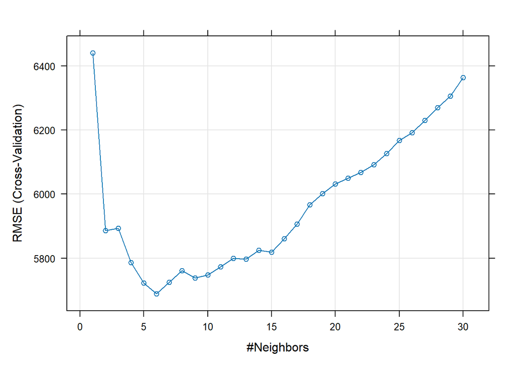

```r
plot(model3)
```

KNN was tuned using 5 fold cross validation on the training data. Values of k from 1 through 30 were considered, and lower RMSE was the requirement. The smallest crossv alidated RMSE was 5688.61 at k = 6, so six nearest neighbors were selected for the final KNN model. Smaller values of k produced a more variable model, while larger values increasingly smoothed predictions and resulted in higher cross validation error.

## Final Model Comparison

```r
# Model 1 predictions
pred1 <- predict(
  model1,
  newdata = test
)

# Model 2 predictions
pred2 <- predict(
  model2,
  newdata = test
)

# Model 3 KNN predictions
pred3 <- predict(
  model3,
  newdata = test
)
```

```r
# Model 1
results1 <- postResample(
  pred = pred1,
  obs = test$charges
)

# Model 2
results2 <- postResample(
  pred = pred2,
  obs = test$charges
)

# Model 3
results3 <- postResample(
  pred = pred3,
  obs = test$charges
)

comparison <- data.frame(
  Model = c(
    "Objective 1 MLR",
    "Feature Selected MLR",
    "KNN"
  ),

  RMSE = c(
    results1["RMSE"],
    results2["RMSE"],
    results3["RMSE"]
  ),

  MAE = c(
    results1["MAE"],
    results2["MAE"],
    results3["MAE"]
  ),

  R_Squared = c(
    results1["Rsquared"],
    results2["Rsquared"],
    results3["Rsquared"]
  )
)

comparison
```

```
##                  Model     RMSE      MAE R_Squared
## 1      Objective 1 MLR 4552.517 2801.177 0.8587408
## 2 Feature Selected MLR 4467.126 2734.231 0.8633619
## 3                  KNN 5294.387 3471.803 0.8042982
```

Three predictive models were evaluated using the same 20% holdout test set: the Objective 1 MLR, a feature selected MLR with additional polynomial and interaction terms, and KNN. The feature selected MLR produced the lowest test RMSE ($4,467.13) and MAE ($2,734.23), as well as the highest test R^2 (0.8634). The baseline Objective 1 MLR performed similarly but had slightly larger prediction errors, with an RMSE of $4,552.52. KNN, tuned to k=6 using five fold cross validation, produced the largest test errors, with an RMSE of $5,294.39. Based on test sample prediction performance, the feature selected MLR would be the optimal predictive model to use